# F4SC. Double Exponential Smoothing

Author

Bertrand Haas

Published

October 30, 2025

# R environment setting

Required libraries:

```r
cran_repo <- "https://ftp.fau.de/cran"
list_Rpack2use <-
  c("rmarkdown",
    "conflicted",
    "devtools",
    "knitr",
    "quarto",
    "bookdown",
    #shiny,
    "DT",
    "Hmisc",
    "tidyverse",
    "magrittr",
    "lubridate",
    "hms",
    "glue",
    "skimr",
    "lobstr",
    "janitor",
    "zeallot",
    "stringi",
    "lemon",
    "crayon",
    "jsonlite",
    #"officer",
    "TSA",
    "tsibble",
    "fable",
    "feasts",
    "imputeTS",
    "readxl",
    "slider",
    "reticulate",
    "aws.s3",
    "paws",
    "RAthena",
    "botor",
    "RPostgres",
    "DBI",
    "RJDBC",
    "dbplyr",
    "arrow",
    "geosphere",
    "viridis")

list_installed_packages <- names(installed.packages()[,2])
for (Rpack in list_Rpack2use) {
  if (! Rpack %in% list_installed_packages) {
    print(paste("Installing", Rpack))
    install.packages(Rpack, repos = cran_repo, )
  } else {
    print(paste(Rpack, "already installed."))
  }
}
```

Loaded librairies:

```r
list_Rpack2load_not <-
  c("conflicted",
    "devtools",
    "paws",
    "RAthena",
    "botor",
    "arrow",
    "RPostgres",
    "DBI",
    "RJDBC",
    "dbplyr",
    "aws.s3",
    "arrow",
    "reticulate",
    "slider",
    "stringi",
    "geosphere",
    "blah")
list_Rpack2load <- setdiff(list_Rpack2use, list_Rpack2load_not)
list_Rpack2load
```

```
 [1] "rmarkdown" "knitr"     "quarto"    "bookdown"  "DT"        "Hmisc"
 [7] "tidyverse" "magrittr"  "lubridate" "hms"       "glue"      "skimr"
[13] "lobstr"    "janitor"   "zeallot"   "lemon"     "crayon"    "jsonlite"
[19] "TSA"       "tsibble"   "fable"     "feasts"    "imputeTS"  "readxl"
[25] "viridis"
```

```r
for (Rpack in list_Rpack2load) {
  library(Rpack, character.only = TRUE)
}

conflicted::conflicts_prefer(pillar::dim_desc)
conflicted::conflicts_prefer(magrittr::extract)
conflicted::conflicts_prefer(dplyr::filter)
conflicted::conflicts_prefer(jsonlite::flatten)
conflicted::conflicts_prefer(hms::hms)
conflicted::conflicts_prefer(dbplyr::ident)
conflicted::conflicts_prefer(lubridate::interval)
conflicted::conflicts_prefer(dplyr::lag)
conflicted::conflicts_prefer(readxl::read_xlsx)
conflicted::conflicts_prefer(magrittr::set_names)
conflicted::conflicts_prefer(dbplyr::sql)
conflicted::conflicts_prefer(Hmisc::src)
conflicted::conflicts_prefer(dplyr::summarize)
conflicted::conflicts_prefer(magrittr::is_in)
```

```r
#To pass if interactive
#rendering <- TRUE
#time_all <- proc.time()

source("./scripts_gal/misc_funs.R")

dir_data <- "./data/"

if (!dir.exists(dir_data)) {
  dir.create(dir_data)
}
```

# Simple exponential smoothing revisited

Let’s introduce the “level” or “smoothed value” at time $t$ at the weighted average of the actual and the forecasts at same time $t$:
$$\begin{equation}
a(t) = \alpha d(t) + (1-\alpha)a(t-1)
\end{equation}$$

So curve $a(t)$ is the smoothed version of $d(t)$, with exponential-kernel smoothing. We saw last time that simple exponential smoothing forecasting is the naive forecast of $a(t)$, namely $f(t+1) = a(t)$.

## Signal and noise

We also saw that we use a weighted average of the actual and the forecast because we do not completely trust the actual.

So, we can see both the actual observation $d(t)$ and the forecast $f(t)$ as both a signal $s(t)$ plus some random component (different for the actual and the forecast):
$$\begin{align*}
d(t) &= s(t) + \eta \\
f(t) &= s(t) + \epsilon
\end{align*}$$
With $\eta$ some noise with variance $V_\eta$ and $\epsilon$ some other noise (with possibly a completely different distribution) with variance $V_\epsilon$. So the variance of $a(t)$ is a function of $\alpha$:
$$\begin{equation}
V(\alpha) = \alpha^2V_\eta + (1 - \alpha)^2 V_\epsilon
\end{equation}$$
Minimizing $V(\alpha)$ yields:
$$\begin{equation}
\alpha = \frac{V_\epsilon}{V_\epsilon + V_\eta}
\end{equation}$$
Of course, since usually we do not know $V_\epsilon$ and $V_\eta$, this should be seen as an explanatory point of view for the moment. For the moment we will limit ourselves to playing with $\alpha$ to get a satisfactory result. But once $\alpha$ satisfactorily chosen, it can be viewed as the ratio above, linking the variances of $d(t)$ and $f(t)$.

# Double exponential smoothing (trend estimation)

We have seen that we can de-trend by differencing. For example for a linear trend differencing only once is enough:

$$\begin{align*}
d(t) &= b_0 + b_1 t + \epsilon \\
d(t-1) &= b_0 + b_1 (t-1) + \epsilon
\end{align*}$$
Therefore
$$\begin{equation}
c(t) = d(t) - d(t-1) = b_1 + \epsilon'
\end{equation}$$
Where for the variances we have $V(\epsilon') = 2 V(\epsilon)$. We see that averaging all the differences $E(c(t))$ should yield a good estimate of the slope $b_1$ of the linear trend. But we have just seen that with a well chosen $\alpha$ we can have a smoothed version $a(t)$ of $d(t)$ with smaller variance. This means that we can better estimate $b_1$ by averaging the differences $a(t) - a(t-1)$. This would work well for a linear trend, but for a non-linear trend, that is smoothly evolving, we might want to put more emphasis (more weight when averaging) on the recent differences than on the past ones. For example we can use an exponentially weighted average, which, as we have seen last time is convenient since we can express it recursively:
$$\begin{equation}
b(t) = \beta (a(t) - a(t-1)) + (1 - \beta) b(t-1)
\end{equation}$$
Here $b(t)$ represents the estimated increase in trend from time $t-1$ to time $t$. Now we can put the level and the trend together. A little less naively than than just taking the smoothed value from time $t$ as our forecast at time $t+1$, we can take the smoothed value plus the estimated trend:
$$\begin{equation}
f(t+1) = a(t) + b(t)
\end{equation}$$
With the two intertwined other recurrence formulae:
$$\begin{align*}
a(t) &= \alpha d(t) + (1-\alpha) (a(t-1) + b(t-1))\\
b(t) &= \beta (a(t) - a(t-1)) + (1-\beta) b(t-1)
\end{align*}$$

## Further horizons

If we are at time $t$ and want to forecast at time $t+2$, we just pretend that $d(t+1) = f(t+1)$ and we get:
$$\begin{align*}
a(t+1) &= \alpha f(t+1) + (1 - \alpha) f(t+1) \\
&= f(t+1) \\
&= a(t) + b(t)
\end{align*}$$
So
$$\begin{align*}
b(t+1) &= \beta b(t) + (1-\beta) b(t) \\
&= b(t)
\end{align*}$$
Now, when replaced in the equation for $f(t+2)$ we get:
$$\begin{align*}
f(t+2) &= a(t+1) + b(t+1) \\
&= a(t) + 2 b(t)
\end{align*}$$
Continuing that way we see that at horizon $k$ we have:
$$\begin{equation}
f(t + k) = a(t) + k b(t)
\end{equation}$$

## Multiplicative vs Additive trend

So far we have seen additive trend. But sometimes it makes sense to consider multiplicative trend:

$$\begin{equation}
f(t+1) = a(t) * b(t)
\end{equation}$$

In that case the trend can be approximated by dividing, not differencing. Instead of
$$\begin{equation}
d(t) = d(t-1) + b_1 + \epsilon
\end{equation}$$
We have
$$\begin{equation}
d(t) = d(t-1) * b_1 + \epsilon
\end{equation}$$
Here again we get a better result by using the smoothed version of the actuals $b_1 \approx \frac{a(t)}{a(t-1)}$. Again, we take a weighted version of this and the previous trend:
$$\begin{equation}
b(t) = \beta \frac{a(t)}{a(t-1)} + (1 - \beta) b(t-1)
\end{equation}$$
Now, the recurrence relation for the smoothing becomes:
$$\begin{equation}
a(t) = \alpha d(t) + (1-\alpha) (a(t-1) * b(t-1))
\end{equation}$$

For higher horizons we now get:
$$\begin{equation}
f(t+k) = a(t) * b(t)^k
\end{equation}$$

## Initialization

For the first values we usually take:
$$\begin{align*}
a(0) &= d(0) \\
b(0) &= d(1) - d(0)
\end{align*}$$

# Damping the trend

One problem with the trend as defined above is that it never stops for larger and larger horizons. To palliate that, we can force formula to forget the trend with a “memory factor” $0 < \phi < 1$:
$$\begin{align*}
a(t) &= \alpha d(t) + (1-\alpha)(a(t-1) + \phi b(t-1)) \\
b(t) &= \beta (a(t) - a(t-1)) + (1-\beta) \phi b(t-1)
\end{align*}$$
So the forecast becomes:
$$\begin{equation*}
f(t+1) = a(t) + \phi b(t)
\end{equation*}$$

More generally, at horizon $k$, we get:
$$\begin{equation*}
f(t+k) = a(t) + (\phi + \phi^2 + \dots + \phi^k) b(t)
\end{equation*}$$

# Hands on data!

Let’s implement double exponential smoothing. We first load our usual synthetic data:

```r
fpath_ts2 <- glue("{dir_data}synthetic_TS_02.tsv")
df_ts2 <-
  read_tsv(fpath_ts2) %>%
  select(year, day, y_2) %>%
  mutate(day_noy = format(day, "0000-%m-%d") %>% as_date) %>% #date with no year
  relocate(day_noy, .after = day) %>%
  rename(d_t = y_2)
df_ts2
```

```
# A tibble: 1,008 × 4
    year day        day_noy      d_t
   <dbl> <date>     <date>     <dbl>
 1  2023 2023-01-01 0000-01-01  2.68
 2  2023 2023-01-02 0000-01-02  1.72
 3  2023 2023-01-03 0000-01-03  3.75
 4  2023 2023-01-04 0000-01-04  3.79
 5  2023 2023-01-05 0000-01-05  4.82
 6  2023 2023-01-06 0000-01-06  1.85
 7  2023 2023-01-07 0000-01-07  2.88
 8  2023 2023-01-08 0000-01-08  2.90
 9  2023 2023-01-09 0000-01-09  2.93
10  2023 2023-01-10 0000-01-10  1.95
# ℹ 998 more rows
```

```r
df_ts2 %<>%
  mutate(d_t = d_t + lag(d_t, default = 0) + lead(d_t, default = 0))

df_ts2
```

```
# A tibble: 1,008 × 4
    year day        day_noy      d_t
   <dbl> <date>     <date>     <dbl>
 1  2023 2023-01-01 0000-01-01  4.40
 2  2023 2023-01-02 0000-01-02  8.15
 3  2023 2023-01-03 0000-01-03  9.26
 4  2023 2023-01-04 0000-01-04 12.4
 5  2023 2023-01-05 0000-01-05 10.5
 6  2023 2023-01-06 0000-01-06  9.55
 7  2023 2023-01-07 0000-01-07  7.63
 8  2023 2023-01-08 0000-01-08  8.71
 9  2023 2023-01-09 0000-01-09  7.79
10  2023 2023-01-10 0000-01-10  7.86
# ℹ 998 more rows
```

```r
alf = 0.4
bet = 0.6
phi  = 0.8
```

Let’s use the following parameters:

- $\alpha = 0.4$
- $\beta = 0.6$
- $\phi = 0.8$

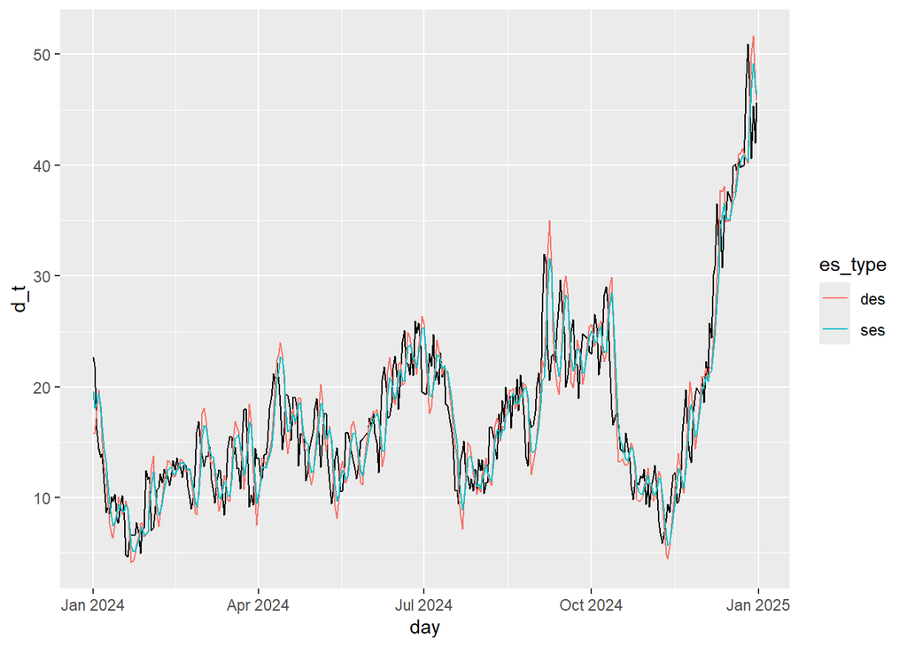

```r
df_ts2 %<>%
  mutate(a_t = -1,
         b_t = -1)

df_ts2$a_t[1] <- df_ts2$d_t[1]
df_ts2$b_t[1] <- df_ts2$d_t[2] - df_ts2$d_t[1]

for (i in 2:nrow(df_ts2)) {
  df_ts2$a_t[i] <- alf * df_ts2$d_t[i-1] + (1-alf) * (df_ts2$a_t[i-1] + df_ts2$b_t[i-1])
  df_ts2$b_t[i] <- bet * (df_ts2$a_t[i] - df_ts2$a_t[i-1]) + (1-bet) * df_ts2$b_t[i-1]
}

df_ts2 %<>%
  mutate(f_ses = lag(a_t),
         f_des = lag(a_t) + lag(b_t))

year_1 <- 2024

df_ts2 %<>%
  pivot_longer(cols = c(f_ses, f_des),
               names_to = "es_type",
               values_to = "fcast",
               names_prefix = "f_")

df_ts2 %>%
  filter(year == year_1) %>%
  ggplot(aes(x = day, y = fcast)) +
    geom_line(aes(y = d_t), color = "black") +
    geom_line(aes(color = es_type))
```

Difficult to see which is better. Let’s compute some KPI accuracy over year 2024, for example WAPE. Recall:

$$\begin{equation}
\mathrm{WAPE} = \frac{\sum |f(t) - d(t)|}{\sum d(t)}
\end{equation}$$

```r
df_ts2 %>%
  mutate(err = fcast - d_t) %>%
  group_by(year, es_type) %>%
  reframe(wape = sum(abs(err), na.rm = TRUE) / sum(d_t) * 100) %>%
  pivot_wider(names_from = es_type,
              values_from = wape)
```

```
# A tibble: 3 × 3
   year   des   ses
  <dbl> <dbl> <dbl>
1  2023  20.2  18.4
2  2024  17.3  15.7
3  2025  18.8  17.2
```

# Homeworks

**Important 1: To do at home**

**Important 2: To do at home**

Implement DESD, Double Exponential Smoothing forecasting with trend Dampening factor $phi = 1, 0.8, 0.5$ for horizon 7 (one week) with the values of $(\alpha, \beta)$ found in Hwk 1. Plot and compute the WAPE for comparison.